# Relation Prediction in Argument Mining With Pre-trained Deep Bidirectional Transformers - Core

```python
# The comparative results on the Political dataset (Task 1: Related/Unrelated).
# 10-Fold stratified cross-validation is used

# Parameters:
# Fixed: input=both, seq_len=256, warmup_prop=0.1, seed=42
# model=base-uncased, epochs=5, batch_size=12, lr=2e-5

# Only run this cell, if the Political Task 1 comparative training has been done
if os.path.isdir("../pytorch/res/pol_ru"):
    # Read the results
    eval_results = pd.read_csv('../pytorch/res/pol_ru/eval_results.tsv', sep='\t')
    # Read the predictions
    eval_preds = pd.read_csv('../pytorch/res/pol_ru/eval_preds.csv')

    # Calculate precision, recall and F1 for all Folds
    preds = pd.Series()
    re_pre_f1_dict = {'Precision related' : [], 'Precision unrelated': [],
                      'Recall related': [], 'Recall unrelated': [], 'F1 related': [], 'F1 unrelated': []}
    scores_df = pd.DataFrame(re_pre_f1_dict)
    count = 0
    for i, row in eval_preds.iterrows():
        preds_split_i = pd.Series(row.values[~row.str.contains('bert*', na=False, regex=True)]).dropna().astype('int8')
        preds_split_i = preds_split_i.replace({0: 'related', 1: 'unrelated'})
        preds = preds.append(preds_split_i)
        length = len(preds_split_i)
        pre, rec, f1, support = precision_recall_fscore_support(pol_ru_test_df.iloc[count:count+length]['label'], preds_split_i, labels=['related', 'unrelated'])
        count += length
        scores_df.loc[i] = np.array((pre,rec,f1)).reshape((1,-1))[0]
        if i == 9:
            break
    pol_ru_test_df['preds'] = preds.values

    # Calculate the macro-averages
    scores_df['Average Precision'] = (scores_df['Precision related']+scores_df['Precision unrelated'])/2
    scores_df['Average Recall'] = (scores_df['Recall related']+scores_df['Recall unrelated'])/2
    scores_df['Average F1'] = (scores_df['F1 related']+scores_df['F1 unrelated'])/2

    print("Precision, Recall, F1, Macro-averages (Mean + std) for Task 1 on all folds:")
    display(scores_df.agg([np.mean, np.std, np.min, np.max]))

    print('Only calculate the scores on the complete predictions:')
    print(classification_report(pol_ru_test_df['label'], pol_ru_test_df['preds'], labels=['related', 'unrelated']))

else:
    print('You have to first reproduce the results for the Polical dataset Task 1.\n'
          'python run_classifier_ba.py  --task_name "political-ru" --output_dir res/pol_ru/crossval1 --do_cross_val --do_lower_case --num_train_epochs 5 --max_seq_length 256 --train_batch_size 12 --learning_rate 2e-5')
```

```
Precision, Recall, F1, Macro-averages (Mean + std) for Task 1 on all folds:
```

|  | Precision related | Precision unrelated | Recall related | Recall unrelated | F1 related | F1 unrelated | Average Precision | Average Recall | Average F1 |
| --- | --- | --- | --- | --- | --- | --- | --- | --- | --- |
| mean | 0.69 | 0.66 | 0.63 | 0.71 | 0.66 | 0.68 | 0.67 | 0.67 | 0.67 |
| std | 0.04 | 0.04 | 0.07 | 0.07 | 0.04 | 0.04 | 0.03 | 0.04 | 0.04 |
| amin | 0.63 | 0.60 | 0.51 | 0.62 | 0.58 | 0.63 | 0.64 | 0.64 | 0.63 |
| amax | 0.75 | 0.72 | 0.70 | 0.78 | 0.72 | 0.74 | 0.73 | 0.73 | 0.73 |

```
Only calculate the scores on the complete predictions:
              precision    recall  f1-score   support

     related       0.69      0.63      0.66       731
   unrelated       0.66      0.71      0.68       729

    accuracy                           0.67      1460
   macro avg       0.67      0.67      0.67      1460
weighted avg       0.67      0.67      0.67      1460
```

```python
# The comparative results on the Political dataset (Task 2: Attack/Support).
# 10-Fold stratified cross-validation is used

# Parameters:
# Fixed: input=both, seq_len=256, warmup_prop=0.1, seed=42
# model=base-uncased, epochs=5, batch_size=12, lr=2e-5

# Only run this cell, if the Political Task 2 comparative training has been done
if os.path.isdir("../pytorch/res/pol_as"):
    # Read the results
    eval_results = pd.read_csv('../pytorch/res/pol_as/eval_results.tsv', sep='\t')
    # Read the predictions
    eval_preds = pd.read_csv('../pytorch/res/pol_as/eval_preds.csv')

    # Calculate precision, recall and F1 for all Folds
    preds = pd.Series()
    re_pre_f1_dict = {'Precision attack' : [], 'Precision support': [],
                  'Recall attack': [], 'Recall support': [], 'F1 attack': [], 'F1 support': []}
    scores_df = pd.DataFrame(re_pre_f1_dict)
    count = 0
    for i, row in eval_preds.iterrows():
        preds_split_i = pd.Series(row.values[~row.str.contains('bert*', na=False, regex=True)]).dropna().astype('int8')
        preds_split_i = preds_split_i.replace({0: 'attack', 1: 'support'})
        preds = preds.append(preds_split_i)
        length = len(preds_split_i)
        pre, rec, f1, support = precision_recall_fscore_support(pol_as_test_df.iloc[count:count+length]['label'], preds_split_i, labels=['attack', 'support'])
        count += length
        scores_df.loc[i] = np.array((pre,rec,f1)).reshape((1,-1))[0]
        if i == 9:
            break
    pol_as_test_df['preds'] = preds.values

    # Calculate the macro-averages
    scores_df['Average Precision'] = (scores_df['Precision attack']+scores_df['Precision support'])/2
    scores_df['Average Recall'] = (scores_df['Recall attack']+scores_df['Recall support'])/2
    scores_df['Average F1'] = (scores_df['F1 attack']+scores_df['F1 support'])/2

    print("Precision, Recall, F1, Macro-averages (Mean + std) for Task 2 on all folds:")
    display(scores_df.agg([np.mean, np.std, np.min, np.max]))

    print('Only calculate the scores on the complete predictions:')
    print(classification_report(pol_as_test_df['label'], pol_as_test_df['preds'], labels=['attack', 'support']))

else:
    print('You have to first reproduce the results for the Polical dataset Task 2.\n'
          'python run_classifier_ba.py  --task_name "political-as" --output_dir res/pol_as/crossval1 --do_cross_val --do_lower_case --num_train_epochs 5 --max_seq_length 256 --train_batch_size 12 --learning_rate 2e-5')
```

```
Precision, Recall, F1, Macro-averages (Mean + std) for Task 2 on all folds:
```

|  | Precision attack | Precision support | Recall attack | Recall support | F1 attack | F1 support | Average Precision | Average Recall | Average F1 |
| --- | --- | --- | --- | --- | --- | --- | --- | --- | --- |
| mean | 0.76 | 0.79 | 0.82 | 0.71 | 0.79 | 0.75 | 0.77 | 0.77 | 0.77 |
| std | 0.06 | 0.05 | 0.05 | 0.08 | 0.04 | 0.06 | 0.05 | 0.05 | 0.05 |
| amin | 0.69 | 0.71 | 0.76 | 0.63 | 0.72 | 0.67 | 0.70 | 0.70 | 0.70 |
| amax | 0.85 | 0.85 | 0.89 | 0.86 | 0.86 | 0.84 | 0.85 | 0.85 | 0.85 |

```
Only calculate the scores on the complete predictions:
              precision    recall  f1-score   support

      attack       0.75      0.82      0.79       378
     support       0.79      0.71      0.75       353

    accuracy                           0.77       731
   macro avg       0.77      0.77      0.77       731
weighted avg       0.77      0.77      0.77       731
```

```python
# The comparative results on the Political dataset (Task 3: Attack/Support/Unrelated).
# 10-Fold stratified cross-validation is used

# Parameters:
# Fixed: input=both, seq_len=256, warmup_prop=0.1, seed=42
# model=base-uncased, epochs=5, batch_size=12, lr=2e-5

# Only run this cell, if the Political Task 3 comparative training has been done
if os.path.isdir("../pytorch/res/pol_asu"):
    # Read the results
    eval_results = pd.read_csv('../pytorch/res/pol_asu/eval_results.tsv', sep='\t')
    # Read the predictions
    eval_preds = pd.read_csv('../pytorch/res/pol_asu/eval_preds.csv')

    # Calculate precision, recall and F1 for all Folds
    preds = pd.Series()
    re_pre_f1_dict = {'Precision attack' : [], 'Precision support': [], 'Precision unrelated': [],
                  'Recall attack': [], 'Recall support': [], 'Recall unrelated': [],
                  'F1 attack': [], 'F1 support': [], 'F1 unrelated': []}
    scores_df = pd.DataFrame(re_pre_f1_dict)
    count = 0
    for i, row in eval_preds.iterrows():
        preds_split_i = pd.Series(row.values[~row.str.contains('bert*', na=False, regex=True)]).dropna().astype('int8')
        preds_split_i = preds_split_i.replace({0: 'attack', 1: 'support', 2: 'unrelated'})
        preds = preds.append(preds_split_i)
        length = len(preds_split_i)
        pre, rec, f1, support = precision_recall_fscore_support(pol_asu_test_df.iloc[count:count+length]['label'], preds_split_i, labels=['attack', 'support', 'unrelated'])
        count += length
        scores_df.loc[i] = np.array((pre,rec,f1)).reshape((1,-1))[0]
        if i == 9:
            break
    pol_asu_test_df['preds'] = preds.values

    # Calculate the macro-averages
    scores_df['Average Precision'] = (scores_df['Precision attack']+scores_df['Precision support']+scores_df['Precision unrelated'])/3
    scores_df['Average Recall'] = (scores_df['Recall attack']+scores_df['Recall support']+scores_df['Recall unrelated'])/3
    scores_df['Average F1'] = (scores_df['F1 attack']+scores_df['F1 support']+scores_df['F1 unrelated'])/3

    print("Precision, Recall, F1, Macro-averages (Mean + std) for Task 3 on all folds:")
    display(scores_df.agg([np.mean, np.std, np.min, np.max]))

    print('Only calculate the scores on the complete predictions:')
    print(classification_report(pol_asu_test_df['label'], pol_asu_test_df['preds'], labels=['attack', 'support', 'unrelated']))

    print('Major class baseline:')
    print(classification_report(pol_asu_test_df['label'], ['unrelated']*1460, labels=['attack', 'support', 'unrelated']))


else:
    print('You have to first reproduce the results for the Polical dataset Task 3.\n'
          'python run_classifier_ba.py  --task_name "political-asu" --output_dir res/pol_asu/crossval1 --do_cross_val --do_lower_case --num_train_epochs 5 --max_seq_length 256 --train_batch_size 12 --learning_rate 2e-5')
```

```
Precision, Recall, F1, Macro-averages (Mean + std) for Task 3 on all folds:
```

|  | Precision attack | Precision support | Precision unrelated | Recall attack | Recall support | Recall unrelated | F1 attack | F1 support | F1 unrelated | Average Precision | Average Recall | Average F1 |
| --- | --- | --- | --- | --- | --- | --- | --- | --- | --- | --- | --- | --- |
| mean | 0.53 | 0.54 | 0.65 | 0.52 | 0.43 | 0.72 | 0.52 | 0.48 | 0.68 | 0.57 | 0.55 | 0.56 |
| std | 0.06 | 0.08 | 0.04 | 0.09 | 0.07 | 0.05 | 0.06 | 0.06 | 0.04 | 0.04 | 0.04 | 0.04 |
| amin | 0.43 | 0.44 | 0.57 | 0.42 | 0.37 | 0.64 | 0.43 | 0.42 | 0.60 | 0.51 | 0.50 | 0.50 |
| amax | 0.60 | 0.67 | 0.71 | 0.68 | 0.61 | 0.79 | 0.63 | 0.60 | 0.74 | 0.66 | 0.63 | 0.63 |

```
Only calculate the scores on the complete predictions:
              precision    recall  f1-score   support

      attack       0.53      0.52      0.52       378
     support       0.54      0.43      0.48       353
   unrelated       0.65      0.72      0.68       729

    accuracy                           0.60      1460
   macro avg       0.57      0.56      0.56      1460
weighted avg       0.59      0.60      0.59      1460

Major class baseline:
              precision    recall  f1-score   support

      attack       0.00      0.00      0.00       378
     support       0.00      0.00      0.00       353
   unrelated       0.50      1.00      0.67       729

    accuracy                           0.50      1460
   macro avg       0.17      0.33      0.22      1460
weighted avg       0.25      0.50      0.33      1460
```

```python
# The comparative results on the Agreement dataset.
# 10-Fold stratified cross-validation is used

# Parameters:
# Fixed: input=both, seq_len=256, warmup_prop=0.1, seed=42
# model=base-uncased, epochs=3, batch_size=12, lr=2e-5

# Only run this cell, if the Agreement comparative training has been done
if os.path.isdir("../pytorch/res/agreement_new"):
    # Read the results
    eval_results = pd.read_csv('../pytorch/res/agreement_new/eval_results.tsv', sep='\t')
    # Read the predictions
    eval_preds = pd.read_csv('../pytorch/res/agreement_new/eval_preds.csv')

    # Calculate precision, recall and F1 for all Folds
    preds = pd.Series()
    re_pre_f1_dict = {'Precision agreement' : [], 'Precision disagreement': [],
                  'Recall agreement': [], 'Recall disagreement': [], 'F1 agreement': [], 'F1 disagreement': [], "Accuracy": []}
    scores_df = pd.DataFrame(re_pre_f1_dict)
    count = 0
    for i, row in eval_preds.iterrows():
        preds_split_i = pd.Series(row.values[~row.str.contains('bert*', na=False, regex=True)]).dropna().astype('int8')
        preds_split_i = preds_split_i.replace({0: 'agreement', 1: 'disagreement'})
        preds = preds.append(preds_split_i)
        length = len(preds_split_i)
        pre, rec, f1, support = precision_recall_fscore_support(ag_test_df.iloc[count:count+length]['label'], preds_split_i, labels=['agreement', 'disagreement'])
        acc = np.array([accuracy_score(ag_test_df.iloc[count:count+length]['label'], preds_split_i)])
        count += length
        scores_df.loc[i] = np.concatenate((pre,rec,f1,acc)).ravel()
        if i == 9:
            break
    ag_test_df['preds'] = preds.values

    print("Precision, Recall, F1, Accuracy (Mean + std) for Agreement on all folds:")
    display(scores_df.agg([np.mean, np.std, np.min, np.max]))


else:
    print('You have to first reproduce the results for the Agreement dataset.\n'
          'python run_classifier_ba.py  --task_name "agreement" --output_dir res/agreement_new/crossval1 --do_cross_val --do_lower_case --num_train_epochs 3 --max_seq_length 256 --train_batch_size 12 --learning_rate 2e-5')
```

```
Precision, Recall, F1, Accuracy (Mean + std) for Agreement on all folds:
```

|  | Precision agreement | Precision disagreement | Recall agreement | Recall disagreement | F1 agreement | F1 disagreement | Accuracy |
| --- | --- | --- | --- | --- | --- | --- | --- |
| mean | 9.66e-01 | 9.68e-01 | 9.65e-01 | 9.69e-01 | 9.66e-01 | 9.69e-01 | 9.67e-01 |
| std | 8.61e-03 | 7.17e-03 | 7.90e-03 | 8.12e-03 | 7.05e-03 | 6.55e-03 | 6.79e-03 |
| amin | 9.44e-01 | 9.58e-01 | 9.54e-01 | 9.48e-01 | 9.49e-01 | 9.53e-01 | 9.51e-01 |
| amax | 9.74e-01 | 9.80e-01 | 9.79e-01 | 9.76e-01 | 9.75e-01 | 9.77e-01 | 9.76e-01 |

## Additional Experiments

In the following the results of the additional experiments are presented.

```python
# The additional procon results on the NoDE dataset. The network is always trained on the train dataset + procon
# and evaluated on the test dataset.

# Parameters:
# Fixed: input=both, seq_len=128, warmup_prop=0.1, seed=42-71
# Tested: model=base-uncased, epochs=4,5, batch_size=12,16, lr=2e-5, 3e-5

# Only run this cell, if the NoDE additional procon training has been done
if os.path.isdir("../pytorch/res/node_both_procon"):
    # Read in all testing results
    eval_results = pd.read_csv('../pytorch/res/node_both_procon/eval_results.tsv', sep='\t')
    # Read in all testing predictions
    eval_preds = pd.read_csv('../pytorch/res/node_both_procon/eval_preds.csv')
    # Group all runs with the same settings (different seeds) together
    eval_results_grouped = eval_results.groupby(['_bert-model', '_num_epochs', '_batch_size','_gradient_acc' ,'_learning_rate' ])
    # Aggregate mean, min, max, std and median
    results = eval_results_grouped['acc'].agg([np.mean, np.min, np.max, np.std, np.median])

    # Print the statistics reported in the thesis
    print("Best mean result with parameters and other statistics:\n", results.loc[results['mean'].idxmax()])
    print("\nOverall mean:\n", eval_results['acc'].mean())
    print("\nWorst (single) run:\n", eval_results['acc'].min())
    print("\nBest (single) run:\n", eval_results['acc'].max())

    # Formats and shows the complete result table
    results = results.reset_index()
    results = results.rename(columns={element: element.replace("_", "-") for element in results.columns.tolist()})
    results = results.rename(columns={element: re.sub("^-", "", element) for element in results.columns.tolist()})
    results = results.replace({"bert-base-uncased": 'bbu', "bert-large-uncased": 'blu'})
    results['batch-size'] = results['batch-size'] * results['gradient-acc']
    results = results.drop(columns=["gradient-acc"])
    results.iloc[:,:8].to_csv('../data/thesis/node_procon_results.csv', index=False)
    print("\nComplete results table:")
    display(results.iloc[:,:8])
else:
    print("You have to first reproduce the results for the NoDE procon dataset.\n"
          "../code_relation_prediction/pytorch ./run_all_node.sh procon")
```

```
Best mean result with parameters and other statistics:
 mean      0.67
amin      0.55
amax      0.76
std       0.05
median    0.68
Name: (bert-base-uncased, 5.0, 12, 1, 2e-05), dtype: float64

Overall mean:
 0.6485833333333333

Worst (single) run:
 0.44

Best (single) run:
 0.76

Complete results table:
```

|  | bert-model | num-epochs | batch-size | learning-rate | mean | amin | amax | std |
| --- | --- | --- | --- | --- | --- | --- | --- | --- |
| 0 | bbu | 4.0 | 12 | 2.00e-05 | 0.65 | 0.52 | 0.75 | 0.05 |
| 1 | bbu | 4.0 | 12 | 3.00e-05 | 0.62 | 0.49 | 0.73 | 0.06 |
| 2 | bbu | 4.0 | 16 | 2.00e-05 | 0.66 | 0.55 | 0.72 | 0.05 |
| 3 | bbu | 4.0 | 16 | 3.00e-05 | 0.64 | 0.53 | 0.75 | 0.06 |
| 4 | bbu | 5.0 | 12 | 2.00e-05 | 0.67 | 0.55 | 0.76 | 0.05 |
| 5 | bbu | 5.0 | 12 | 3.00e-05 | 0.63 | 0.50 | 0.72 | 0.06 |
| 6 | bbu | 5.0 | 16 | 2.00e-05 | 0.66 | 0.55 | 0.74 | 0.05 |
| 7 | bbu | 5.0 | 16 | 3.00e-05 | 0.65 | 0.44 | 0.75 | 0.06 |

```python
# The additional results on the Political dataset (Task 1+2).
# 5-Fold leave-one-group-out (topics) cross-validation is used

# Parameters:
# Fixed: input=both, seq_len=256, warmup_prop=0.1, seed=42
# model=base-uncased, epochs=5, batch_size=12, lr=2e-5

# Only run this cell, if the Political Task 1 additional training has been done
if os.path.isdir("../pytorch/res/pol_ru_topics"):
    # Load results
    eval_results = pd.read_csv('../pytorch/res/pol_ru_topics/eval_results.tsv', sep='\t')
    # Aggregate and display
    print("Task 1:")
    results = eval_results.groupby(['_bert-model', '_num_epochs', '_batch_size','_gradient_acc' ,'_learning_rate'])['f1'].agg([np.mean, np.min, np.max, np.std])
    display(results)
else:
    print('You have to first reproduce the results for the Political Task 1 additional dataset.\n'
          '../code_relation_prediction/pytorch python run_classifier_ba.py  --task_name "political-ru-topics" --output_dir res/pol_ru_topics/crossval1 --do_cross_val --do_lower_case --num_train_epochs 5 --max_seq_length 256 --train_batch_size 12 --learning_rate 2e-5')

# Only run this cell, if the Political Task 2 additional training has been done
if os.path.isdir("../pytorch/res/pol_as_topics"):
    # Load results
    eval_results = pd.read_csv('../pytorch/res/pol_as_topics/eval_results.tsv', sep='\t')
    # Aggregate and display
    print("Task 2:")
    results = eval_results.groupby(['_bert-model', '_num_epochs', '_batch_size','_gradient_acc' ,'_learning_rate'])['f1'].agg([np.mean, np.min, np.max, np.std])
    display(results)
else:
    print('You have to first reproduce the results for the Political Task 2 additional dataset.\n'
          '../code_relation_prediction/pytorch python run_classifier_ba.py  --task_name "political-as-topics" --output_dir res/pol_as_topics/crossval1 --do_cross_val --do_lower_case --num_train_epochs 5 --max_seq_length 256 --train_batch_size 12 --learning_rate 2e-5')
```

```
Task 1:
```

| _bert-model | _num_epochs | _batch_size | _gradient_acc | _learning_rate | mean | amin | amax | std |
| --- | --- | --- | --- | --- | --- | --- | --- | --- |
| bert-base-uncased | 5.0 | 12 | 1 | 2.00e-05 | 0.59 | 0.56 | 0.64 | 0.04 |

```
Task 2:
```

| _bert-model | _num_epochs | _batch_size | _gradient_acc | _learning_rate | mean | amin | amax | std |
| --- | --- | --- | --- | --- | --- | --- | --- | --- |
| bert-base-uncased | 5.0 | 12 | 1 | 2.00e-05 | 0.63 | 0.53 | 0.69 | 0.07 |

```python
# The additional results on the Agreement dataset.
# Topic independent 80/20 train/test split

# Parameters:
# Fixed: input=both, seq_len=256, warmup_prop=0.1, seed=42
# model=base-uncased, epochs=3, batch_size=12, lr=2e-5

# Only run this cell, if the Political Task 2 additional training has been done
if os.path.isdir("../pytorch/res/agreement_topics_new"):
    # Load results
    eval_results = pd.read_csv('../pytorch/res/agreement_topics_new/eval_results.tsv', sep='\t')
    # Aggregate and display
    results = eval_results.groupby(['_bert-model', '_num_epochs', '_batch_size','_gradient_acc' ,'_learning_rate'])['f1'].agg([np.mean, np.min, np.max, np.std])
    display(results)
else:
    print('You have to first reproduce the results for the Agreement additional dataset.\n'
          '../code_relation_prediction/pytorch python run_classifier_ba.py  --task_name "agreement-topics" --output_dir res/agreement_topics_new/train_test1 --do_train --do_eval --do_lower_case --num_train_epochs 3 --max_seq_length 256 --train_batch_size 12 --learning_rate 2e-5')
```

| _bert-model | _num_epochs | _batch_size | _gradient_acc | _learning_rate | mean | amin | amax | std |
| --- | --- | --- | --- | --- | --- | --- | --- | --- |
| bert-base-uncased | 3.0 | 12 | 1 | 2.00e-05 | 0.79 | 0.79 | 0.79 | NaN |

```python
# The additional only org results on the NoDE dataset. The network is always trained on the train dataset
# and evaluated on the test dataset.

# Parameters:
# Fixed: input=org, seq_len=128, warmup_prop=0.1, seed=42-71
# Tested: model=base-uncased, epochs=4,5, batch_size=12,16, lr=2e-5, 3e-5

# Only run this cell, if the NoDE additional org training has been done
if os.path.isdir("../pytorch/res/node_org"):
    # Read in all testing results
    eval_results = pd.read_csv('../pytorch/res/node_org/eval_results.tsv', sep='\t')
    # Read in all testing predictions
    eval_preds = pd.read_csv('../pytorch/res/node_org/eval_preds.csv')
    # Group all runs with the same settings (different seeds) together
    eval_results_grouped = eval_results.groupby(['_bert-model', '_num_epochs', '_batch_size','_gradient_acc' ,'_learning_rate' ])
    # Aggregate mean, min, max, std and median
    results = eval_results_grouped['acc'].agg([np.mean, np.min, np.max, np.std, np.median])

    # Print the statistics reported in the thesis
    print("Best mean result with parameters and other statistics:\n", results.loc[results['mean'].idxmax()])
    print("\nOverall mean:\n", eval_results['acc'].mean())
    print("\nWorst (single) run:\n", eval_results['acc'].min())
    print("\nBest (single) run:\n", eval_results['acc'].max())

    # Formats and shows the complete result table
    results = results.reset_index()
    results = results.rename(columns={element: element.replace("_", "-") for element in results.columns.tolist()})
    results = results.rename(columns={element: re.sub("^-", "", element) for element in results.columns.tolist()})
    results = results.replace({"bert-base-uncased": 'bbu', "bert-large-uncased": 'blu'})
    results['batch-size'] = results['batch-size'] * results['gradient-acc']
    results = results.drop(columns=["gradient-acc"])
    results.iloc[:,:8].to_csv('../data/thesis/node_onlyorg_results.csv', index=False)
    print("\nComplete results table:")
    display(results.iloc[:,:8])
else:
    print("You have to first reproduce the results for the NoDE org dataset.\n"
          "../code_relation_prediction/pytorch ./run_all_node.sh only")
```

```
Best mean result with parameters and other statistics:
 mean      0.64
amin      0.58
amax      0.67
std       0.02
median    0.65
Name: (bert-base-uncased, 4.0, 16, 1, 2.9999999999999997e-05), dtype: float64

Overall mean:
 0.63125

Worst (single) run:
 0.41

Best (single) run:
 0.7

Complete results table:
```

|  | bert-model | num-epochs | batch-size | learning-rate | mean | amin | amax | std |
| --- | --- | --- | --- | --- | --- | --- | --- | --- |
| 0 | bbu | 4.0 | 12 | 2.00e-05 | 0.63 | 0.55 | 0.67 | 0.04 |
| 1 | bbu | 4.0 | 12 | 3.00e-05 | 0.62 | 0.55 | 0.70 | 0.04 |
| 2 | bbu | 4.0 | 16 | 2.00e-05 | 0.62 | 0.45 | 0.67 | 0.05 |
| 3 | bbu | 4.0 | 16 | 3.00e-05 | 0.64 | 0.58 | 0.67 | 0.02 |
| 4 | bbu | 5.0 | 12 | 2.00e-05 | 0.64 | 0.44 | 0.66 | 0.04 |
| 5 | bbu | 5.0 | 12 | 3.00e-05 | 0.64 | 0.41 | 0.68 | 0.05 |
| 6 | bbu | 5.0 | 16 | 2.00e-05 | 0.63 | 0.55 | 0.66 | 0.03 |
| 7 | bbu | 5.0 | 16 | 3.00e-05 | 0.62 | 0.41 | 0.67 | 0.06 |

```python
# The additional results on the Political dataset (Task 1+2).
# 10-Fold stratified cross-validation is used

# Parameters:
# Fixed: input=org, seq_len=256, warmup_prop=0.1, seed=42
# model=base-uncased, epochs=5, batch_size=12, lr=2e-5

# Only run this cell, if the Political Task 1 additional org training has been done
if os.path.isdir("../pytorch/res/pol_ru_org"):
    # Load results
    eval_results = pd.read_csv('../pytorch/res/pol_ru_org/eval_results.tsv', sep='\t')
    # Aggregate and display
    print("Task 1:")
    results = eval_results.groupby(['_bert-model', '_num_epochs', '_batch_size','_gradient_acc' ,'_learning_rate'])['f1'].agg([np.mean, np.min, np.max, np.std])
    display(results)
else:
    print('You have to first reproduce the results for the Political Task 1 additional org dataset.\n'
          '../code_relation_prediction/pytorch python run_classifier_ba.py  --task_name "political-as" --output_dir res/pol_as_org/crossval1 --input_to_use "org" --do_cross_val --do_lower_case --num_train_epochs 5 --max_seq_length 256 --train_batch_size 12 --learning_rate 2e-5')
# Only run this cell, if the Political Task 2 additional org training has been done
if os.path.isdir("../pytorch/res/pol_as_org"):
    # Load results
    eval_results = pd.read_csv('../pytorch/res/pol_as_org/eval_results.tsv', sep='\t')
    # Aggregate and display
    print("Task 2:")
    results = eval_results.groupby(['_bert-model', '_num_epochs', '_batch_size','_gradient_acc' ,'_learning_rate'])['f1'].agg([np.mean, np.min, np.max, np.std])
    display(results)
else:
    print('You have to first reproduce the results for the Political Task 2 additional org dataset.\n'
          '../code_relation_prediction/pytorch python run_classifier_ba.py  --task_name "political-ru" --output_dir res/pol_ru_org/crossval1 --input_to_use "org" --do_cross_val --do_lower_case --num_train_epochs 5 --max_seq_length 256 --train_batch_size 12 --learning_rate 2e-5')
```

```
Task 1:
```

| _bert-model | _num_epochs | _batch_size | _gradient_acc | _learning_rate | mean | amin | amax | std |
| --- | --- | --- | --- | --- | --- | --- | --- | --- |
| bert-base-uncased | 5.0 | 12 | 1 | 2.00e-05 | 0.61 | 0.52 | 0.72 | 0.06 |

```
Task 2:
```

| _bert-model | _num_epochs | _batch_size | _gradient_acc | _learning_rate | mean | amin | amax | std |
| --- | --- | --- | --- | --- | --- | --- | --- | --- |
| bert-base-uncased | 5.0 | 12 | 1 | 2.00e-05 | 0.55 | 0.31 | 0.68 | 0.15 |

```python
# The additional only resp results on the NoDE dataset. The network is always trained on the train dataset
# and evaluated on the test dataset.

# Parameters:
# Fixed: input=response, seq_len=128, warmup_prop=0.1, seed=42-71
# Tested: model=base-uncased, epochs=4,5, batch_size=12,16, lr=2e-5, 3e-5

# Only run this cell, if the NoDE additional org training has been done
if os.path.isdir("../pytorch/res/node_resp"):
    # Read in all testing results
    eval_results = pd.read_csv('../pytorch/res/node_resp/eval_results.tsv', sep='\t')
    # Read in all testing predictions
    eval_preds = pd.read_csv('../pytorch/res/node_resp/eval_preds.csv')
    # Group all runs with the same settings (different seeds) together
    eval_results_grouped = eval_results.groupby(['_bert-model', '_num_epochs', '_batch_size','_gradient_acc' ,'_learning_rate' ])
    # Aggregate mean, min, max, std and median
    results = eval_results_grouped['acc'].agg([np.mean, np.min, np.max, np.std, np.median])

    # Print the statistics reported in the thesis
    print("Best mean result with parameters and other statistics:\n", results.loc[results['mean'].idxmax()])
    print("\nOverall mean:\n", eval_results['acc'].mean())
    print("\nWorst (single) run:\n", eval_results['acc'].min())
    print("\nBest (single) run:\n", eval_results['acc'].max())

    # Formats and shows the complete result table
    results = results.reset_index()
    results = results.rename(columns={element: element.replace("_", "-") for element in results.columns.tolist()})
    results = results.rename(columns={element: re.sub("^-", "", element) for element in results.columns.tolist()})
    results = results.replace({"bert-base-uncased": 'bbu', "bert-large-uncased": 'blu'})
    results['batch-size'] = results['batch-size'] * results['gradient-acc']
    results = results.drop(columns=["gradient-acc"])
    results.iloc[:,:8].to_csv('../data/thesis/node_onlyresp_results.csv', index=False)
    print("\nComplete results table:")
    display(results.iloc[:,:8])
else:
    print("You have to first reproduce the results for the NoDE resp dataset.\n"
          "../code_relation_prediction/pytorch ./run_all_node.sh only")
```

```
Best mean result with parameters and other statistics:
 mean      0.58
amin      0.47
amax      0.69
std       0.06
median    0.57
Name: (bert-base-uncased, 5.0, 12, 1, 2.9999999999999997e-05), dtype: float64

Overall mean:
 0.5655

Worst (single) run:
 0.43

Best (single) run:
 0.69

Complete results table:
```

|  | bert-model | num-epochs | batch-size | learning-rate | mean | amin | amax | std |
| --- | --- | --- | --- | --- | --- | --- | --- | --- |
| 0 | bbu | 4.0 | 12 | 2.00e-05 | 0.56 | 0.46 | 0.63 | 0.04 |
| 1 | bbu | 4.0 | 12 | 3.00e-05 | 0.56 | 0.44 | 0.65 | 0.05 |
| 2 | bbu | 4.0 | 16 | 2.00e-05 | 0.57 | 0.48 | 0.67 | 0.04 |
| 3 | bbu | 4.0 | 16 | 3.00e-05 | 0.55 | 0.43 | 0.67 | 0.05 |
| 4 | bbu | 5.0 | 12 | 2.00e-05 | 0.57 | 0.47 | 0.68 | 0.05 |
| 5 | bbu | 5.0 | 12 | 3.00e-05 | 0.58 | 0.47 | 0.69 | 0.06 |
| 6 | bbu | 5.0 | 16 | 2.00e-05 | 0.55 | 0.45 | 0.62 | 0.04 |
| 7 | bbu | 5.0 | 16 | 3.00e-05 | 0.58 | 0.50 | 0.66 | 0.05 |

```python
# The additional results on the Political dataset (Task 1+2).
# 10-Fold stratified cross-validation is used

# Parameters:
# Fixed: input=response, seq_len=256, warmup_prop=0.1, seed=42
# model=base-uncased, epochs=5, batch_size=12, lr=2e-5

# Only run this cell, if the Political Task 1 additional resp training has been done
if os.path.isdir("../pytorch/res/pol_ru_resp"):
    # Load results
    eval_results = pd.read_csv('../pytorch/res/pol_ru_resp/eval_results.tsv', sep='\t')
    # Aggregate and display
    print("Task 1:")
    results = eval_results.groupby(['_bert-model', '_num_epochs', '_batch_size','_gradient_acc' ,'_learning_rate'])['f1'].agg([np.mean, np.min, np.max, np.std])
    display(results)
else:
    print('You have to first reproduce the results for the Political Task 1 additional resp dataset.\n'
          '../code_relation_prediction/pytorch python run_classifier_ba.py  --task_name "political-as" --output_dir res/pol_as_resp/crossval1 --input_to_use "response" --do_cross_val --do_lower_case --num_train_epochs 5 --max_seq_length 256 --train_batch_size 12 --learning_rate 2e-5')
# Only run this cell, if the Political Task 2 additional resp training has been done
if os.path.isdir("../pytorch/res/pol_as_resp"):
    # Load results
    eval_results = pd.read_csv('../pytorch/res/pol_as_resp/eval_results.tsv', sep='\t')
    # Aggregate and display
    print("Task 2:")
    results = eval_results.groupby(['_bert-model', '_num_epochs', '_batch_size','_gradient_acc' ,'_learning_rate'])['f1'].agg([np.mean, np.min, np.max, np.std])
    display(results)
else:
    print('You have to first reproduce the results for the Political Task 2 additional resp dataset.\n'
          '../code_relation_prediction/pytorch python run_classifier_ba.py  --task_name "political-ru" --output_dir res/pol_ru_resp/crossval1 --input_to_use "response" --do_cross_val --do_lower_case --num_train_epochs 5 --max_seq_length 256 --train_batch_size 12 --learning_rate 2e-5')
```

```
Task 1:
```

| _bert-model | _num_epochs | _batch_size | _gradient_acc | _learning_rate | mean | amin | amax | std |
| --- | --- | --- | --- | --- | --- | --- | --- | --- |
| bert-base-uncased | 5.0 | 12 | 1 | 2.00e-05 | 0.62 | 0.55 | 0.69 | 0.05 |

```
Task 2:
```

| _bert-model | _num_epochs | _batch_size | _gradient_acc | _learning_rate | mean | amin | amax | std |
| --- | --- | --- | --- | --- | --- | --- | --- | --- |
| bert-base-uncased | 5.0 | 12 | 1 | 2.00e-05 | 0.62 | 0.52 | 0.71 | 0.06 |

```python
# The additional reversed results on the NoDE dataset. The network is always trained on the train dataset
# and evaluated on the test dataset.

# Parameters:
# Fixed: input=resp-org, seq_len=128, warmup_prop=0.1, seed=42-71
# Tested: model=base-uncased, epochs=4,5, batch_size=12,16, lr=2e-5, 3e-5

# Only run this cell, if the NoDE additional org training has been done
if os.path.isdir("../pytorch/res/node_both_reversed"):
    # Read in all testing results
    eval_results = pd.read_csv('../pytorch/res/node_both_reversed/eval_results.tsv', sep='\t')
    # Read in all testing predictions
    eval_preds = pd.read_csv('../pytorch/res/node_both_reversed/eval_preds.csv')
    # Group all runs with the same settings (different seeds) together
    eval_results_grouped = eval_results.groupby(['_bert-model', '_num_epochs', '_batch_size','_gradient_acc' ,'_learning_rate' ])
    # Aggregate mean, min, max, std and median
    results = eval_results_grouped['acc'].agg([np.mean, np.min, np.max, np.std, np.median])

    # Print the statistics reported in the thesis
    print("Best mean result with parameters and other statistics:\n", results.loc[results['mean'].idxmax()])
    print("\nOverall mean:\n", eval_results['acc'].mean())
    print("\nWorst (single) run:\n", eval_results['acc'].min())
    print("\nBest (single) run:\n", eval_results['acc'].max())

    # Formats and shows the complete result table
    results = results.reset_index()
    results = results.rename(columns={element: element.replace("_", "-") for element in results.columns.tolist()})
    results = results.rename(columns={element: re.sub("^-", "", element) for element in results.columns.tolist()})
    results = results.replace({"bert-base-uncased": 'bbu', "bert-large-uncased": 'blu'})
    results['batch-size'] = results['batch-size'] * results['gradient-acc']
    results = results.drop(columns=["gradient-acc"])
    results.iloc[:,:8].to_csv('../data/thesis/node_resporg_results.csv', index=False)
    print("\nComplete results table:")
    display(results.iloc[:,:8])
else:
    print("You have to first reproduce the results for the NoDE resp dataset.\n"
          "../code_relation_prediction/pytorch ./run_all_node.sh resporg")
```

```
Best mean result with parameters and other statistics:
 mean      0.62
amin      0.47
amax      0.70
std       0.05
median    0.63
Name: (bert-base-uncased, 5.0, 16, 1, 2e-05), dtype: float64

Overall mean:
 0.6078333333333333

Worst (single) run:
 0.43

Best (single) run:
 0.71

Complete results table:
```

|  | bert-model | num-epochs | batch-size | learning-rate | mean | amin | amax | std |
| --- | --- | --- | --- | --- | --- | --- | --- | --- |
| 0 | bbu | 4.0 | 12 | 2.00e-05 | 0.60 | 0.55 | 0.69 | 0.04 |
| 1 | bbu | 4.0 | 12 | 3.00e-05 | 0.61 | 0.55 | 0.68 | 0.05 |
| 2 | bbu | 4.0 | 16 | 2.00e-05 | 0.60 | 0.48 | 0.68 | 0.05 |
| 3 | bbu | 4.0 | 16 | 3.00e-05 | 0.61 | 0.50 | 0.68 | 0.04 |
| 4 | bbu | 5.0 | 12 | 2.00e-05 | 0.62 | 0.50 | 0.70 | 0.05 |
| 5 | bbu | 5.0 | 12 | 3.00e-05 | 0.61 | 0.45 | 0.71 | 0.06 |
| 6 | bbu | 5.0 | 16 | 2.00e-05 | 0.62 | 0.47 | 0.70 | 0.05 |
| 7 | bbu | 5.0 | 16 | 3.00e-05 | 0.60 | 0.43 | 0.69 | 0.05 |

```python
# The additional reversed results on the Political dataset (Task 1+2).
# 10-Fold stratified cross-validation is used

# Parameters:
# Fixed: input=resp-org, seq_len=256, warmup_prop=0.1, seed=42
# model=base-uncased, epochs=5, batch_size=12, lr=2e-5

# Only run this cell, if the Political Task 1 additional resp-org training has been done
if os.path.isdir("../pytorch/res/pol_ru_resporg"):
    # Load results
    eval_results = pd.read_csv('../pytorch/res/pol_ru_resporg/eval_results.tsv', sep='\t')
    # Aggregate and display
    print("Task 1:")
    results = eval_results.groupby(['_bert-model', '_num_epochs', '_batch_size','_gradient_acc' ,'_learning_rate'])['f1'].agg([np.mean, np.min, np.max, np.std])
    display(results)
else:
    print('You have to first reproduce the results for the Political Task 1 additional resp-org dataset.\n'
          '../code_relation_prediction/pytorch python run_classifier_ba.py  --task_name "political-as" --output_dir res/pol_as_resporg/crossval1 --input_to_use "response-org" --do_cross_val --do_lower_case --num_train_epochs 5 --max_seq_length 256 --train_batch_size 12 --learning_rate 2e-5')
# Only run this cell, if the Political Task 2 additional resp-org training has been done
if os.path.isdir("../pytorch/res/pol_as_resporg"):
    # Load results
    eval_results = pd.read_csv('../pytorch/res/pol_as_resporg/eval_results.tsv', sep='\t')
    # Aggregate and display
    print("Task 2:")
    results = eval_results.groupby(['_bert-model', '_num_epochs', '_batch_size','_gradient_acc' ,'_learning_rate'])['f1'].agg([np.mean, np.min, np.max, np.std])
    display(results)
else:
    print('You have to first reproduce the results for the Political Task 2 additional resp-org dataset.\n'
          '../code_relation_prediction/pytorch python run_classifier_ba.py  --task_name "political-ru" --output_dir res/pol_ru_resporg/crossval1 --input_to_use "response-org" --do_cross_val --do_lower_case --num_train_epochs 5 --max_seq_length 256 --train_batch_size 12 --learning_rate 2e-5')
```

```
Task 1:
```

| _bert-model | _num_epochs | _batch_size | _gradient_acc | _learning_rate | mean | amin | amax | std |
| --- | --- | --- | --- | --- | --- | --- | --- | --- |
| bert-base-uncased | 5.0 | 12 | 1 | 2.00e-05 | 0.68 | 0.64 | 0.75 | 0.03 |

```
Task 2:
```

| _bert-model | _num_epochs | _batch_size | _gradient_acc | _learning_rate | mean | amin | amax | std |
| --- | --- | --- | --- | --- | --- | --- | --- | --- |
| bert-base-uncased | 5.0 | 12 | 1 | 2.00e-05 | 0.79 | 0.67 | 0.84 | 0.06 |

## Critical Analysis

Critical Analysis

- Duplicates in Agreement
- Author distributon + unique argument author
- WordClouds Author
- NoDe:
  - Major
  - Major by topic
  - Sent 1+2
  - Output in respect to the topics
- Pol:
  - RU:
    - Major
    - Major by topic
    - Major by org
    - Major by response
    - Major by author
    - Performance over topics (10-CV, 5-CV)
  - AS:
    - Major
    - Major by topic
    - Major by org
    - Major by response
    - Major by author
    - Sent 1+2
    - Performance over topics (10-CV, 5-CV)
- Agreement:
  - Major
  - Major by topic
  - Performance over topics (10-CV, train/test)

```python
# The first few duplicates in the agreement Dataset (~4000 arg1,arg2 pairs occur twice, sometimes in different topics)
print("Agreement Duplicates:")
df_check = df[df['org_dataset'] == 'agreement']
display(df_check[df_check.duplicated(subset=['org', 'response'], keep=False)].head())
```

```
Agreement Duplicates:
```

|  | org_dataset | id | org | org_stance | response | response_stance | label | topic | org_len | response_len | complete_len |
| --- | --- | --- | --- | --- | --- | --- | --- | --- | --- | --- | --- |
| 1729 | agreement | 10 | $700b bailout is important to stabilize volati... | unknown | $700 billion bailout plan is too little too la... | unknown | disagreement | bailout | 82 | 130 | 212 |
| 1730 | agreement | 11 | $700b bailout is important to stabilize volati... | unknown | $700 billion bailout plan is too little too la... | unknown | disagreement | plan | 82 | 130 | 212 |
| 1731 | agreement | 12 | $700b bailout is important to stabilize volati... | unknown | $700b bailout would increase US deficit and in... | unknown | disagreement | bailout | 82 | 196 | 278 |
| 1732 | agreement | 13 | $700b bailout is important to stabilize volati... | unknown | $700b bailout would increase US deficit and in... | unknown | disagreement | plan | 82 | 196 | 278 |
| 1733 | agreement | 14 | $700b bailout is important to stabilize volati... | unknown | No assurances that a $700b bailout would work ... | unknown | disagreement | bailout | 82 | 59 | 141 |

```python
# Political by author
# Same author mostly support each other
# Different authors mostly attack each other
# Dataset is heavily imbalanced in respect to the author, Kennedy occurs way more often
print("Number of unique arguments per author:")
display(data_nix_ken.groupby("author").nunique())
print("Label distribution for the different author combinations:")
data_stats_author.iloc[:,:-2].to_csv('../data/thesis/author_imbalance.csv', index=False)
display(data_stats_author.iloc[:,:-2].style.background_gradient(cmap='Blues'))
```

```
Number of unique arguments per author:
```

| author | author | text |
| --- | --- | --- |
| Kennedy | 1 | 739 |
| Nixon | 1 | 326 |

```
Label distribution for the different author combinations:
```

|  | Author resp | Author org | Unique arguments | Total pairs | Attack | Support | Unrelated |
| --- | --- | --- | --- | --- | --- | --- | --- |
| 0 | Kennedy | Kennedy | 496 | 467 | 2 | 195 | 270 |
| 1 | Kennedy | Nixon | 501 | 418 | 172 | 55 | 191 |
| 2 | Nixon | Kennedy | 493 | 460 | 202 | 42 | 216 |
| 3 | Nixon | Nixon | 154 | 115 | 2 | 61 | 52 |
| 4 | Total | nan | 1065 | 1460 | 378 | 353 | 729 |

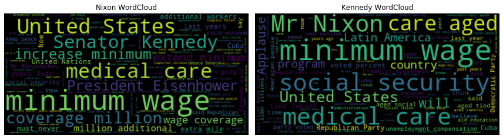

```python
# Wordclouds for Kennedy and for Nixon
# Both often say the name of the other candidate, Nixon talks about Predisdent Eisenhower
fig, (ax1,ax2) = plt.subplots(1,2, figsize=(12,10))  # 1 row, 2 columns

stopwords = set(STOPWORDS)
wordcloud = WordCloud(
    stopwords=stopwords, random_state=5).generate(
    " ".join(text for text in data_nix_ken.loc[data_nix_ken["author"] == 'Nixon', 'text']))
ax1.imshow(wordcloud, interpolation="bilinear")
ax1.set_title("Nixon WordCloud")
ax1.set_axis_off()
wordcloud = WordCloud(
    stopwords=stopwords, random_state=5).generate(
    " ".join(text for text in data_nix_ken.loc[data_nix_ken["author"] == 'Kennedy', 'text']))
ax2.imshow(wordcloud, interpolation="bilinear")
ax2.set_title("Kennedy WordCloud")
ax2.set_axis_off()


plt.tight_layout()
plt.savefig('../data/thesis/authors_wordcloud.pdf', bbox_inches='tight')
```

```python
# All Baselines for the NoDE (test) dataset + Predictions on NoDE with respect to the topcis

# Major class baseline
data = data_stats_topic['debate_test']
data['major_acc'] = data.apply(get_major_acc, args=[['Attack','Support']], axis=1)
data['major_class'] = data.apply(get_major_class, args=[['Attack','Support']], axis=1)
data = data.set_index('Topic')
print("Major class baseline NoDe test:")
display(data.iloc[-1:])

# Major class topic baseline
print("Major class by topic NoDe test:")
display(data)
print("Major by topic baseline overall NoDe test:\n")
node_test_df['major_topic_pred'] = node_test_df['topic'].apply(
    lambda r: data.loc[r, 'major_class']).replace({'Attack': 'attack', 'Support': 'support'})
print(classification_report(node_test_df['label'], node_test_df['major_topic_pred']))

# Sentiment baseliness
node_test_df['org_polarity'] = node_test_df['org'].apply(lambda r: disc_pol(sid.polarity_scores(r)['compound']))
node_test_df['resp_polarity'] = node_test_df['response'].apply(lambda r: disc_pol(sid.polarity_scores(r)['compound']))
node_test_df['sent_both_baseline'] = node_test_df.apply(
    lambda r: 'attack' if r['org_polarity'] != r['resp_polarity'] else 'support', axis=1)
node_test_df['sent_resp_baseline'] = node_test_df.apply(
    lambda r: 'attack' if r['resp_polarity'] == 'negative' else 'support', axis=1)
print("\nSentimen 1 baseline (both arguments same sent==support, otherwise==attack):\n")
print(classification_report(node_test_df['label'], node_test_df['sent_both_baseline']))
print("\nSentiment 2 baseline (response negative sentiment==attack, otherwise==support):\n")
print(classification_report(node_test_df['label'], node_test_df['sent_resp_baseline']))

# Predictions with respect to the topics (only if NoDE comparative was trained)
if os.path.isdir("../pytorch/res/node_both_paper"):
    # Load the data
    eval_results = pd.read_csv('../pytorch/res/node_both_paper/eval_results.tsv', sep='\t')
    eval_results_grouped = eval_results.groupby(['_bert-model', '_num_epochs', '_batch_size','_gradient_acc' ,'_learning_rate' ])
    eval_preds = pd.read_csv('../pytorch/res/node_both_paper/eval_preds.csv')
    results = eval_results_grouped['acc'].agg([np.mean, np.min, np.max, np.std, np.median])
    bmodel, bepochs, bb, bga, blr = results.loc[results['mean'].idxmax()].name
    best_pred_ps = eval_results.loc[(eval_results['_bert-model'] == bmodel) &
                           (eval_results['_num_epochs'] == bepochs) & (eval_results['_batch_size'] == bb) &
                           (eval_results['_learning_rate'] == blr)].index

    # Take the rounded mean prediction for all runs of the best setting
    res = pd.concat([node_test_df.reset_index(drop=True), eval_preds.iloc[best_pred_ps,:-1].transpose().reset_index(drop=True)], axis=1)
    res['Mean prediction'] = res[list(best_pred_ps)].mean(axis=1).round().values
    res = res.replace({0: 'attack', 1: 'support'})
    res = res.rename(columns={'label': 'Label'})

    print("\nPredictions of the best setting (rounded) with respect to the topics:")
    pd.crosstab(res['topic'], [res['Label'],res['Mean prediction']]).to_csv('../data/thesis/node_topics_preds.csv', index=True)
    display(pd.crosstab(res['topic'], [res['Label'],res['Mean prediction']]))
else:
    print("You have to first reproduce the results for the NoDE dataset.\n"
          "../code_relation_prediction/pytorch ./run_all_node.sh comp")
```

```
Major class baseline NoDe test:
```

| Topic | Unique arguments | Total pairs | Attack | Support | Median combined tokens | Max combined tokens | major_acc | major_class |
| --- | --- | --- | --- | --- | --- | --- | --- | --- |
| Total | 113 | 100 | 45 | 55 | 80.5 | 200.0 | 0.55 | Support |

```
Major class by topic NoDe test:
```

| Topic | Unique arguments | Total pairs | Attack | Support | Median combined tokens | Max combined tokens | major_acc | major_class |
| --- | --- | --- | --- | --- | --- | --- | --- | --- |
| Cellphones | 11 | 10 | 5 | 5 | 80.0 | 159.0 | 0.50 | Attack |
| Gasvehicles | 13 | 11 | 6 | 5 | 86.0 | 133.0 | 0.55 | Attack |
| Gaymarriage | 7 | 6 | 2 | 4 | 96.0 | 142.0 | 0.67 | Support |
| Groundzeromosque | 7 | 5 | 5 | 0 | 93.0 | 155.0 | 1.00 | Attack |
| Internetaccess | 2 | 1 | 1 | 0 | 152.0 | 152.0 | 1.00 | Attack |
| Marijuanafree | 17 | 16 | 6 | 10 | 69.0 | 163.0 | 0.62 | Support |
| Militaryservice | 13 | 12 | 6 | 6 | 60.5 | 103.0 | 0.50 | Attack |
| Noflyzone | 11 | 10 | 4 | 6 | 76.5 | 126.0 | 0.60 | Support |
| Securityprofiling | 9 | 8 | 4 | 4 | 88.0 | 129.0 | 0.50 | Attack |
| Solarenergy | 16 | 15 | 4 | 11 | 59.0 | 111.0 | 0.73 | Support |
| Vegetarianism | 7 | 6 | 2 | 4 | 96.5 | 200.0 | 0.67 | Support |
| Total | 113 | 100 | 45 | 55 | 80.5 | 200.0 | 0.55 | Support |

```
Major by topic baseline overall NoDe test:

              precision    recall  f1-score   support

      attack       0.57      0.60      0.59        45
     support       0.66      0.64      0.65        55

    accuracy                           0.62       100
   macro avg       0.62      0.62      0.62       100
weighted avg       0.62      0.62      0.62       100


Sentimen 1 baseline (both arguments same sent==support, otherwise==attack):

              precision    recall  f1-score   support

      attack       0.61      0.51      0.55        45
     support       0.65      0.73      0.68        55

    accuracy                           0.63       100
   macro avg       0.63      0.62      0.62       100
weighted avg       0.63      0.63      0.63       100


Sentiment 2 baseline (response negative sentiment==attack, otherwise==support):

              precision    recall  f1-score   support

      attack       0.52      0.56      0.54        45
     support       0.62      0.58      0.60        55

    accuracy                           0.57       100
   macro avg       0.57      0.57      0.57       100
weighted avg       0.57      0.57      0.57       100


Predictions of the best setting (rounded) with respect to the topics:
```

| Label Mean prediction topic | attack | attack support | support attack | support |
| --- | --- | --- | --- | --- |
| Cellphones | 1 | 4 | 0 | 5 |
| Gasvehicles | 4 | 2 | 1 | 4 |
| Gaymarriage | 1 | 1 | 0 | 4 |
| Groundzeromosque | 1 | 4 | 0 | 0 |
| Internetaccess | 1 | 0 | 0 | 0 |
| Marijuanafree | 1 | 5 | 1 | 9 |
| Militaryservice | 6 | 0 | 3 | 3 |
| Noflyzone | 1 | 3 | 1 | 5 |
| Securityprofiling | 1 | 3 | 0 | 4 |
| Solarenergy | 2 | 2 | 0 | 11 |
| Vegetarianism | 2 | 0 | 0 | 4 |

```python
# All Baselines for the Political (Task 1) dataset + Predictions with respect to the topcis

# Major class baseline
data = data_stats_topic['political']
data['related'] = data.apply(lambda r: r['Attack'] + r['Support'], axis=1)
data['major_acc'] = data.apply(get_major_acc, args=[['related', 'Unrelated']], axis=1)
data['major_class'] = data.apply(get_major_class, args=[['related', 'Unrelated']], axis=1)
data = data.set_index('Topic')
pol_ru_test_df['major_class'] = 'related'
print("Major class Political RU:\n")
print(classification_report(pol_ru_test_df['label'], pol_ru_test_df['major_class']))

# Major class topic baseline
print("\nMajor class by topic Political RU:\n")
pol_ru_test_df['major_topic_pred'] = pol_ru_test_df['topic'].apply(
    lambda r: data.loc[r, 'major_class']).replace({'Unrelated': 'unrelated'})
print(classification_report(pol_ru_test_df['label'], pol_ru_test_df['major_topic_pred']))

# Author major class baseline
data = data_stats_author.copy()
data['related'] = data.apply(lambda r: r['Attack'] + r['Support'], axis=1)
data['major_acc'] = data.apply(get_major_acc, args=[['related', 'Unrelated']], axis=1)
data['major_class'] = data.apply(get_major_class, args=[['related', 'Unrelated']], axis=1)
data = data.set_index(['Author resp', 'Author org'])
pol_ru_test_df['major_author'] = pol_ru_test_df.apply(
    lambda r: data.loc[r['response_stance'], r['org_stance']]['major_class'], axis=1).replace({'Unrelated': 'unrelated'})
print("\nAuthor major class baseline RU:\n")
print(classification_report(pol_ru_test_df['label'], pol_ru_test_df['major_author']))
display(data)

# Major class per original argument baseline (excluding all arguments only occurring once)
df = pol_ru_test_df.copy()
data = df.groupby('org').apply(
    lambda r: pd.Series({'org': r['org'].iloc[0], 'related': count_values(r, ['related']),
                         'unrelated': count_values(r, ['unrelated'])}))
data['major_acc'] = data.apply(get_major_acc, args=[['related', 'unrelated']], axis=1)
data['major_class'] = data.apply(get_major_class, args=[['related', 'unrelated']], axis=1)
data = data.set_index('org')
data['total'] = data['related'] + data['unrelated']
# Drop all arguments only occurring once
orgs_only_once = data.loc[data['total'] == 1].index.to_list()
index = df[df['org'].isin(orgs_only_once)].index
df = df.drop(index)
df['major_org_pred'] = df['org'].apply(lambda r: data.loc[r, 'major_class'])
print("\nMajor class by original argument RU:\n")
print(classification_report(df['label'], df['major_org_pred']))

# Major class by response argument baseline (excluding all arguments only occurring once)
df = pol_ru_test_df.copy()
data = df.groupby('response').apply(
    lambda r: pd.Series({'resp': r['response'].iloc[0], 'related': count_values(r, ['related']),
                         'unrelated': count_values(r, ['unrelated'])}))
data['major_acc'] = data.apply(get_major_acc, args=[['related', 'unrelated']], axis=1)
data['major_class'] = data.apply(get_major_class, args=[['related', 'unrelated']], axis=1)
data = data.set_index('resp')
data['total'] = data['related'] + data['unrelated']
# Drop all arguments only occurring once
orgs_only_once = data.loc[data['total'] == 1].index.to_list()
index = df[df['response'].isin(orgs_only_once)].index
df = df.drop(index)
df['major_resp_pred'] = df['response'].apply(lambda r: data.loc[r, 'major_class'])
print("\nMajor class by response argument RU:\n")
print(classification_report(df['label'], df['major_resp_pred']))

# Predictions with respect to the topics (only if Political Task1 comparative was trained)
if os.path.isdir("../pytorch/res/pol_ru"):
    # Load the data
    eval_preds = pd.read_csv('../pytorch/res/pol_ru/eval_preds.csv')
    print("\nPredictions with respect to the topics RU:\n")
    convert_preds_topic(eval_preds, pol_ru_test_df, {0: 'related', 1: 'unrelated'}, 9)
else:
    print('You have to first reproduce the results for the Political Task 1 dataset.\n'
          'python run_classifier_ba.py  --task_name "political-ru" --output_dir res/pol_ru/crossval1 --do_cross_val --do_lower_case --num_train_epochs 5 --max_seq_length 256 --train_batch_size 12 --learning_rate 2e-5')

# Predictions with respect to the topics (only if Political Task1 additional was trained)
if os.path.isdir("../pytorch/res/pol_ru_topics"):
    # Load the data
    eval_preds = pd.read_csv('../pytorch/res/pol_ru_topics/eval_preds.csv', names=list(range(0,315))).iloc[1:]
    print("\nPredictions with respect to the topics RU (indepedent version):\n")
    convert_preds_topic(eval_preds, pol_ru_to_test_df, {0: 'related', 1: 'unrelated'}, 5)
else:
    print('You have to first reproduce the results for the Political Task 1 (topic independent) dataset.\n'
          '../code_relation_prediction/pytorch python run_classifier_ba.py  --task_name "political-ru-topics" --output_dir res/pol_ru_topics/crossval1 --do_cross_val --do_lower_case --num_train_epochs 5 --max_seq_length 256 --train_batch_size 12 --learning_rate 2e-5')
```

```
Major class Political RU:

              precision    recall  f1-score   support

     related       0.50      1.00      0.67       731
   unrelated       0.00      0.00      0.00       729

    accuracy                           0.50      1460
   macro avg       0.25      0.50      0.33      1460
weighted avg       0.25      0.50      0.33      1460


Major class by topic Political RU:

              precision    recall  f1-score   support

     related       0.59      0.73      0.65       731
   unrelated       0.64      0.48      0.55       729

    accuracy                           0.61      1460
   macro avg       0.61      0.61      0.60      1460
weighted avg       0.61      0.61      0.60      1460
```

```
Author major class baseline RU:

              precision    recall  f1-score   support

     related       0.54      0.73      0.62       731
   unrelated       0.58      0.37      0.45       729

    accuracy                           0.55      1460
   macro avg       0.56      0.55      0.54      1460
weighted avg       0.56      0.55      0.54      1460
```

| Author resp | Author org | Unique arguments | Total pairs | Attack | Support | Unrelated | Median combined tokens | Max combined tokens | related | major_acc | major_class |
| --- | --- | --- | --- | --- | --- | --- | --- | --- | --- | --- | --- |
| Kennedy | Kennedy | 496 | 467 | 2 | 195 | 270 | 188.0 | 588.0 | 197 | 0.58 | Unrelated |
|  | Nixon | 501 | 418 | 172 | 55 | 191 | 221.0 | 593.0 | 227 | 0.54 | related |
| Nixon | Kennedy | 493 | 460 | 202 | 42 | 216 | 208.0 | 531.0 | 244 | 0.53 | related |
|  | Nixon | 154 | 115 | 2 | 61 | 52 | 211.0 | 556.0 | 63 | 0.55 | related |
| Total | NaN | 1065 | 1460 | 378 | 353 | 729 | 207.0 | 593.0 | 731 | 0.50 | related |

```
Major class by original argument RU:

              precision    recall  f1-score   support

     related       0.72      0.88      0.79       527
   unrelated       0.84      0.63      0.72       496

    accuracy                           0.76      1023
   macro avg       0.78      0.76      0.75      1023
weighted avg       0.77      0.76      0.76      1023


Major class by response argument RU:

              precision    recall  f1-score   support

     related       0.72      0.91      0.81       561
   unrelated       0.86      0.62      0.72       510

    accuracy                           0.77      1071
   macro avg       0.79      0.76      0.76      1071
weighted avg       0.79      0.77      0.77      1071


Predictions with respect to the topics RU:

Topic: cuba
              precision    recall  f1-score   support

     related       0.49      0.31      0.38        78
   unrelated       0.74      0.86      0.80       180

    accuracy                           0.69       258
   macro avg       0.62      0.58      0.59       258
weighted avg       0.67      0.69      0.67       258

Topic: disarmament
              precision    recall  f1-score   support

     related       0.75      0.72      0.73       184
```

[output cut: 20 more lines]

```
   unrelated       0.56      0.61      0.58       107

    accuracy                           0.70       312
   macro avg       0.67      0.68      0.68       312
weighted avg       0.71      0.70      0.70       312

Topic: unemployment
              precision    recall  f1-score   support

     related       0.56      0.44      0.50       117
   unrelated       0.66      0.76      0.71       170

    accuracy                           0.63       287
   macro avg       0.61      0.60      0.60       287
weighted avg       0.62      0.63      0.62       287
```

| label preds topic | related | related unrelated | unrelated related | unrelated | total | correctness |
| --- | --- | --- | --- | --- | --- | --- |
| unemployment | 52 | 65 | 41 | 129 | 287 | 0.63 |
| medical care,health care | 100 | 47 | 59 | 83 | 289 | 0.63 |
| cuba | 24 | 54 | 25 | 155 | 258 | 0.69 |
| disarmament | 133 | 51 | 45 | 85 | 314 | 0.69 |
| minimum wage | 154 | 51 | 42 | 65 | 312 | 0.70 |

```
Predictions with respect to the topics RU (indepedent version):

Topic: cuba
              precision    recall  f1-score   support

     related       0.39      0.85      0.53        78
   unrelated       0.86      0.42      0.57       180

    accuracy                           0.55       258
   macro avg       0.63      0.63      0.55       258
weighted avg       0.72      0.55      0.56       258

Topic: disarmament
              precision    recall  f1-score   support

     related       0.67      0.82      0.74       184
   unrelated       0.63      0.43      0.51       130

    accuracy                           0.66       314
   macro avg       0.65      0.63      0.62       314
weighted avg       0.65      0.66      0.64       314

Topic: medical care,health care
              precision    recall  f1-score   support

     related       0.57      0.77      0.65       147
   unrelated       0.62      0.39      0.48       142

    accuracy                           0.58       289
   macro avg       0.60      0.58      0.57       289
weighted avg       0.59      0.58      0.57       289

Topic: minimum wage
              precision    recall  f1-score   support

     related       0.77      0.47      0.58       205
   unrelated       0.42      0.74      0.54       107

    accuracy                           0.56       312
   macro avg       0.60      0.60      0.56       312
weighted avg       0.65      0.56      0.57       312

Topic: unemployment
              precision    recall  f1-score   support

     related       0.56      0.55      0.55       117
   unrelated       0.69      0.70      0.70       170

    accuracy                           0.64       287
   macro avg       0.62      0.62      0.62       287
weighted avg       0.64      0.64      0.64       287
```

| label preds topic | related | related unrelated | unrelated related | unrelated | total | correctness |
| --- | --- | --- | --- | --- | --- | --- |
| cuba | 66 | 12 | 104 | 76 | 258 | 0.55 |
| minimum wage | 96 | 109 | 28 | 79 | 312 | 0.56 |
| medical care,health care | 113 | 34 | 86 | 56 | 289 | 0.58 |
| unemployment | 64 | 53 | 51 | 119 | 287 | 0.64 |
| disarmament | 151 | 33 | 74 | 56 | 314 | 0.66 |

```python
# All Baselines for the Political (Task 2) dataset + Predictions with respect to the topcis

# Major class baseline
data = data_stats_topic['political']
data['major_acc'] = data.apply(get_major_acc, args=[['Attack', 'Support']], axis=1)
data['major_class'] = data.apply(get_major_class, args=[['Attack', 'Support']], axis=1)
data = data.set_index('Topic')
pol_as_test_df['major_class'] = 'attack'
print("Major class Political As:\n")
print(classification_report(pol_as_test_df['label'], pol_as_test_df['major_class']))

# Major class topic baseline
print("\nMajor class by topic Political AS:\n")
pol_as_test_df['major_topic_pred'] = pol_as_test_df['topic'].apply(
    lambda r: data.loc[r, 'major_class']).replace({'Attack': 'attack', 'Support': 'support'})
print(classification_report(pol_as_test_df['label'], pol_as_test_df['major_topic_pred']))

# Author major class baseline
data = data_stats_author.copy()
data['major_acc'] = data.apply(get_major_acc, args=[['Attack', 'Support']], axis=1)
data['major_class'] = data.apply(get_major_class, args=[['Attack', 'Support']], axis=1)
data = data.set_index(['Author resp', 'Author org'])
pol_as_test_df['major_author'] = pol_as_test_df.apply(
    lambda r: data.loc[r['response_stance'], r['org_stance']]['major_class'], axis=1).replace(
    {'Attack': 'attack', 'Support': 'support'})
print("\nAuthor major class baseline AS:\n")
print(classification_report(pol_as_test_df['label'], pol_as_test_df['major_author']))
display(data)

# Major class per original argument baseline (excluding all arguments only occurring once)
df = pol_as_test_df.copy()
data = df.groupby('org').apply(
    lambda r: pd.Series({'org': r['org'].iloc[0], 'attack': count_values(r, ['attack']),
                         'support': count_values(r, ['support'])}))
data['major_acc'] = data.apply(get_major_acc, args=[['attack', 'support']], axis=1)
data['major_class'] = data.apply(get_major_class, args=[['attack', 'support']], axis=1)
data = data.set_index('org')
data['total'] = data['attack'] + data['support']
# Drop all arguments only occurring once
orgs_only_once = data.loc[data['total'] == 1].index.to_list()
index = df[df['org'].isin(orgs_only_once)].index
df = df.drop(index)
df['major_org_pred'] = df['org'].apply(lambda r: data.loc[r, 'major_class'])
print("\nMajor class by original argument AS:\n")
print(classification_report(df['label'], df['major_org_pred']))

# Major class by response argument baseline (excluding all arguments only occurring once)
df = pol_as_test_df.copy()
data = df.groupby('response').apply(
    lambda r: pd.Series({'resp': r['response'].iloc[0], 'attack': count_values(r, ['attack']),
                         'support': count_values(r, ['support'])}))
data['major_acc'] = data.apply(get_major_acc, args=[['attack', 'support']], axis=1)
data['major_class'] = data.apply(get_major_class, args=[['attack', 'support']], axis=1)
data = data.set_index('resp')
data['total'] = data['attack'] + data['support']
# Drop all arguments only occurring once
orgs_only_once = data.loc[data['total'] == 1].index.to_list()
index = df[df['response'].isin(orgs_only_once)].index
df = df.drop(index)
df['major_resp_pred'] = df['response'].apply(lambda r: data.loc[r, 'major_class'])
print("\nMajor class by response argument AS:\n")
print(classification_report(df['label'], df['major_resp_pred']))

# Sentiment baselines
df = pol_as_test_df.copy()
df['org_polarity'] = df['org'].apply(lambda r: disc_pol(sid.polarity_scores(r)['compound']))
df['resp_polarity'] = df['response'].apply(lambda r: disc_pol(sid.polarity_scores(r)['compound']))
df['sent_both_baseline'] = df.apply(
    lambda r: 'attack' if r['org_polarity'] != r['resp_polarity'] else 'support', axis=1)
df['sent_resp_baseline'] = df.apply(
    lambda r: 'attack' if r['resp_polarity'] == 'negative' else 'support', axis=1)
print("\nSentimen 1 baseline (both arguments same sent==support, otherwise==attack):\n")
print(classification_report(df['label'], df['sent_both_baseline']))
print("\nSentiment 2 baseline (response negative sentiment==attack, otherwise==support):\n")
print(classification_report(df['label'], df['sent_resp_baseline']))

# Predictions with respect to the topics (only if Political Task1 comparative was trained)
if os.path.isdir("../pytorch/res/pol_as"):
    # Load the data
    eval_preds = pd.read_csv('../pytorch/res/pol_as/eval_preds.csv')
    print("\nPredictions with respect to the topics AS:\n")
    convert_preds_topic(eval_preds, pol_as_test_df, {0: 'attack', 1: 'support'}, 9)
else:
    print('You have to first reproduce the results for the Political Task 2 dataset.\n'
          'python run_classifier_ba.py  --task_name "political-as" --output_dir res/pol_as/crossval1 --do_cross_val --do_lower_case --num_train_epochs 5 --max_seq_length 256 --train_batch_size 12 --learning_rate 2e-5')

# Predictions with respect to the topics (only if Political Task1 additional was trained)
if os.path.isdir("../pytorch/res/pol_as_topics"):
    # Load the data
    eval_preds = pd.read_csv('../pytorch/res/pol_as_topics/eval_preds.csv', names=list(range(0,315))).iloc[1:]
    print("\nPredictions with respect to the topics AS (indepedent version):\n")
    convert_preds_topic(eval_preds, pol_as_to_test_df, {0: 'attack', 1: 'support'}, 5)
else:
    print('You have to first reproduce the results for the Political Task 2 (topic independent) dataset.\n'
          '../code_relation_prediction/pytorch python run_classifier_ba.py  --task_name "political-as-topics" --output_dir res/pol_as_topics/crossval1 --do_cross_val --do_lower_case --num_train_epochs 5 --max_seq_length 256 --train_batch_size 12 --learning_rate 2e-5')
```

```
Major class Political As:

              precision    recall  f1-score   support

      attack       0.52      1.00      0.68       378
     support       0.00      0.00      0.00       353

    accuracy                           0.52       731
   macro avg       0.26      0.50      0.34       731
weighted avg       0.27      0.52      0.35       731


Major class by topic Political AS:

              precision    recall  f1-score   support

      attack       0.56      0.70      0.62       378
     support       0.56      0.42      0.48       353

    accuracy                           0.56       731
   macro avg       0.56      0.56      0.55       731
weighted avg       0.56      0.56      0.55       731


Author major class baseline AS:
```

```
              precision    recall  f1-score   support

      attack       0.79      0.99      0.88       378
     support       0.98      0.73      0.84       353

    accuracy                           0.86       731
   macro avg       0.89      0.86      0.86       731
weighted avg       0.89      0.86      0.86       731
```

| Author resp | Author org | Unique arguments | Total pairs | Attack | Support | Unrelated | Median combined tokens | Max combined tokens | major_acc | major_class |
| --- | --- | --- | --- | --- | --- | --- | --- | --- | --- | --- |
| Kennedy | Kennedy | 496 | 467 | 2 | 195 | 270 | 188.0 | 588.0 | 0.99 | Support |
|  | Nixon | 501 | 418 | 172 | 55 | 191 | 221.0 | 593.0 | 0.76 | Attack |
| Nixon | Kennedy | 493 | 460 | 202 | 42 | 216 | 208.0 | 531.0 | 0.83 | Attack |
|  | Nixon | 154 | 115 | 2 | 61 | 52 | 211.0 | 556.0 | 0.97 | Support |
| Total | NaN | 1065 | 1460 | 378 | 353 | 729 | 207.0 | 593.0 | 0.52 | Attack |

```
Major class by original argument AS:

              precision    recall  f1-score   support

      attack       0.78      0.95      0.85       232
     support       0.91      0.67      0.77       190

    accuracy                           0.82       422
   macro avg       0.85      0.81      0.81       422
weighted avg       0.84      0.82      0.82       422


Major class by response argument AS:

              precision    recall  f1-score   support

      attack       0.78      0.92      0.84       265
     support       0.86      0.65      0.74       200

    accuracy                           0.80       465
   macro avg       0.82      0.79      0.79       465
weighted avg       0.81      0.80      0.80       465


Sentimen 1 baseline (both arguments same sent==support, otherwise==attack):

              precision    recall  f1-score   support

      attack       0.52      0.28      0.36       378
     support       0.48      0.72      0.58       353

    accuracy                           0.49       731
   macro avg       0.50      0.50      0.47       731
weighted avg       0.50      0.49      0.47       731


Sentiment 2 baseline (response negative sentiment==attack, otherwise==support):

              precision    recall  f1-score   support

```

[output cut: 44 more lines]

```
     support       0.92      0.85      0.88        80

    accuracy                           0.91       205
   macro avg       0.91      0.90      0.91       205
weighted avg       0.91      0.91      0.91       205

Topic: unemployment
              precision    recall  f1-score   support

      attack       0.73      0.83      0.77        64
     support       0.75      0.62      0.68        53

    accuracy                           0.74       117
   macro avg       0.74      0.73      0.73       117
weighted avg       0.74      0.74      0.73       117
```

| label preds topic | attack | attack support | support attack | support | total | correctness |
| --- | --- | --- | --- | --- | --- | --- |
| medical care,health care | 54 | 21 | 25 | 47 | 147 | 0.69 |
| disarmament | 54 | 22 | 31 | 77 | 184 | 0.71 |
| cuba | 30 | 8 | 13 | 27 | 78 | 0.73 |
| unemployment | 53 | 11 | 20 | 33 | 117 | 0.74 |
| minimum wage | 119 | 6 | 12 | 68 | 205 | 0.91 |

```
Predictions with respect to the topics AS (indepedent version):

Topic: cuba
              precision    recall  f1-score   support

      attack       0.69      0.53      0.60        38
     support       0.63      0.78      0.70        40

    accuracy                           0.65        78
   macro avg       0.66      0.65      0.65        78
weighted avg       0.66      0.65      0.65        78

Topic: disarmament
              precision    recall  f1-score   support

      attack       0.47      0.20      0.28        76
     support       0.60      0.84      0.70       108

    accuracy                           0.58       184
   macro avg       0.53      0.52      0.49       184
weighted avg       0.55      0.58      0.53       184

Topic: medical care,health care
              precision    recall  f1-score   support

      attack       0.80      0.52      0.63        75
     support       0.63      0.86      0.73        72

    accuracy                           0.69       147
   macro avg       0.71      0.69      0.68       147
weighted avg       0.72      0.69      0.68       147

Topic: minimum wage
              precision    recall  f1-score   support

      attack       0.93      0.44      0.60       125
     support       0.52      0.95      0.67        80

    accuracy                           0.64       205
   macro avg       0.73      0.69      0.64       205
weighted avg       0.77      0.64      0.63       205

Topic: unemployment
              precision    recall  f1-score   support

      attack       0.75      0.66      0.70        64
     support       0.64      0.74      0.68        53

    accuracy                           0.69       117
   macro avg       0.69      0.70      0.69       117
weighted avg       0.70      0.69      0.69       117
```

| label preds topic | attack | attack support | support attack | support | total | correctness |
| --- | --- | --- | --- | --- | --- | --- |
| disarmament | 15 | 61 | 17 | 91 | 184 | 0.58 |
| minimum wage | 55 | 70 | 4 | 76 | 205 | 0.64 |
| cuba | 20 | 18 | 9 | 31 | 78 | 0.65 |
| medical care,health care | 39 | 36 | 10 | 62 | 147 | 0.69 |
| unemployment | 42 | 22 | 14 | 39 | 117 | 0.69 |

```python
# All Baselines for the Agreement dataset + Predictions with respect to the topcis

# Major class baseline
data = data_stats_topic['agreement']
data['major_acc'] = data.apply(get_major_acc, args=[['Agreement', 'Disagreement']], axis=1)
data['major_class'] = data.apply(get_major_class, args=[['Agreement', 'Disagreement']], axis=1)
data = data.set_index('Topic')
ag_test_df['major_class'] = 'disagreement'
print("Major class Agreement:\n")
print(classification_report(ag_test_df['label'], ag_test_df['major_class']))

# Major class topic baseline
print("\nMajor class by topic Agreement:\n")
ag_test_df['major_topic_pred'] = ag_test_df['topic'].apply(
    lambda r: data.loc[r, 'major_class']).replace({'Agreement': 'agreement', 'Disagreement': 'disagreement'})
print(classification_report(ag_test_df['label'], ag_test_df['major_topic_pred']))


# Predictions with respect to the topics (only if Agreement comparative was trained)
if os.path.isdir("../pytorch/res/agreement_new"):
    # Load the data
    eval_preds = pd.read_csv('../pytorch/res/agreement_new/eval_preds.csv')
    print("\nPredictions with respect to the topics:\n")
    convert_preds_topic(eval_preds, ag_test_df, {0: 'agreement', 1: 'disagreement'}, 9, False)
else:
    print('You have to first reproduce the results for the Agreement dataset.\n'
          'python run_classifier_ba.py  --task_name "agreement" --output_dir res/agreement_new/crossval1 --do_cross_val --do_lower_case --num_train_epochs 3 --max_seq_length 256 --train_batch_size 12 --learning_rate 2e-5')

# Predictions with respect to the topics (only if Agreement additional was trained)
if os.path.isdir("../pytorch/res/agreement_topics_new"):
    # Load the data
    eval_preds = pd.read_csv('../pytorch/res/agreement_topics_new/eval_preds.csv')
    print("\nPredictions with respect to the topics (indepedent version):\n")
    convert_preds_topic(eval_preds, ag_to_test_df, {0: 'agreement', 1: 'disagreement'}, 1, False)
else:
    print('You have to first reproduce the results for the Political Task 2 (topic independent) dataset.\n'
          '../code_relation_prediction/pytorch python run_classifier_ba.py  --task_name "agreement_topics" --output_dir res/agreement_topics_new/crossval1 --do_cross_val --do_lower_case --num_train_epochs 3 --max_seq_length 256 --train_batch_size 12 --learning_rate 2e-5')
```

```
Major class Agreement:
```

```
              precision    recall  f1-score   support

   agreement       0.00      0.00      0.00     14035
disagreement       0.52      1.00      0.69     15306

    accuracy                           0.52     29341
   macro avg       0.26      0.50      0.34     29341
weighted avg       0.27      0.52      0.36     29341


Major class by topic Agreement:

              precision    recall  f1-score   support

   agreement       0.53      0.23      0.32     14035
disagreement       0.53      0.82      0.65     15306

    accuracy                           0.53     29341
   macro avg       0.53      0.52      0.48     29341
weighted avg       0.53      0.53      0.49     29341


Predictions with respect to the topics:
```

| label preds topic | agreement | agreement disagreement | disagreement agreement | disagreement | total | correctness |
| --- | --- | --- | --- | --- | --- | --- |
| property | 4 | 7 | 5 | 12 | 28 | 0.57 |
| paparazzi | 3 | 2 | 2 | 3 | 10 | 0.60 |
| smoking | 6 | 2 | 3 | 6 | 17 | 0.71 |
| sovereignty | 11 | 9 | 3 | 19 | 42 | 0.71 |
| cloning | 43 | 10 | 13 | 26 | 92 | 0.75 |
| removal | 18 | 2 | 6 | 9 | 35 | 0.77 |
| clone | 9 | 4 | 2 | 14 | 29 | 0.79 |
| veil | 22 | 4 | 5 | 26 | 57 | 0.84 |
| scan | 9 | 2 | 1 | 10 | 22 | 0.86 |
| advertising | 8 | 2 | 1 | 12 | 23 | 0.87 |
| kangaroo | 17 | 4 | 1 | 20 | 42 | 0.88 |
| incest | 67 | 10 | 10 | 87 | 174 | 0.89 |
| socialism | 55 | 6 | 8 | 55 | 124 | 0.89 |
| police | 22 | 2 | 4 | 28 | 56 | 0.89 |
| facebook | 12 | 2 | 1 | 14 | 29 | 0.90 |
| monarchy | 40 | 7 | 3 | 48 | 98 | 0.90 |
| evolution | 33 | 3 | 3 | 20 | 59 | 0.90 |
| water | 138 | 16 | 17 | 168 | 339 | 0.90 |
| mosque | 32 | 3 | 5 | 46 | 86 | 0.91 |
| breastfeeding | 7 | 0 | 1 | 3 | 11 | 0.91 |
| journalism | 18 | 1 | 3 | 22 | 44 | 0.91 |
| laser | 51 | 6 | 3 | 40 | 100 | 0.91 |
| condom | 117 | 9 | 11 | 104 | 241 | 0.92 |
| sanction | 59 | 7 | 4 | 71 | 141 | 0.92 |
| mission | 75 | 7 | 5 | 69 | 156 | 0.92 |
| technique | 14 | 2 | 1 | 22 | 39 | 0.92 |
| juvenile | 18 | 1 | 2 | 19 | 40 | 0.93 |
| membership | 15 | 2 | 1 | 22 | 40 | 0.93 |
| suicide | 5 | 0 | 1 | 8 | 14 | 0.93 |
| hunting | 12 | 0 | 2 | 14 | 28 | 0.93 |

[output cut: 134 more lines]

```
Predictions with respect to the topics (indepedent version):
```

| label preds topic | agreement | agreement disagreement | disagreement agreement | disagreement | total | correctness |
| --- | --- | --- | --- | --- | --- | --- |
| removal | 17 | 3 | 13 | 2 | 35 | 0.54 |
| superdelegates | 43 | 30 | 35 | 47 | 155 | 0.58 |
| warming | 109 | 46 | 77 | 94 | 326 | 0.62 |
| cap-and-trade | 39 | 30 | 23 | 50 | 142 | 0.63 |
| playoff | 10 | 5 | 9 | 16 | 40 | 0.65 |
| food | 135 | 58 | 64 | 138 | 395 | 0.69 |
| police | 17 | 7 | 10 | 22 | 56 | 0.70 |
| abortion | 156 | 65 | 62 | 163 | 446 | 0.72 |
| cloning | 42 | 9 | 15 | 19 | 85 | 0.72 |
| count | 19 | 9 | 7 | 25 | 60 | 0.73 |
| killing | 34 | 10 | 15 | 37 | 96 | 0.74 |
| facebook | 11 | 3 | 4 | 11 | 29 | 0.76 |
| primary | 70 | 20 | 26 | 82 | 198 | 0.77 |
| ban | 186 | 42 | 51 | 184 | 463 | 0.80 |
| torture | 85 | 18 | 26 | 105 | 234 | 0.81 |
| oil | 116 | 25 | 22 | 104 | 267 | 0.82 |
| multiculturalism | 36 | 10 | 9 | 53 | 108 | 0.82 |
| porn | 28 | 4 | 8 | 32 | 72 | 0.83 |
| euthanasia | 61 | 10 | 10 | 47 | 128 | 0.84 |
| prostitution | 33 | 5 | 8 | 38 | 84 | 0.85 |
| exchange | 38 | 1 | 13 | 39 | 91 | 0.85 |
| circumcision | 281 | 36 | 48 | 245 | 610 | 0.86 |
| power | 156 | 25 | 25 | 162 | 368 | 0.86 |
| reforestation | 10 | 3 | 0 | 13 | 26 | 0.88 |
| gas | 191 | 24 | 27 | 231 | 473 | 0.89 |
| bailout | 81 | 8 | 8 | 93 | 190 | 0.92 |
| experiment | 7 | 1 | 0 | 4 | 12 | 0.92 |
| biofuel | 14 | 0 | 1 | 18 | 33 | 0.97 |
| voting | 1 | 0 | 0 | 1 | 2 | 1.00 |
| vegetarianism | 3 | 0 | 0 | 1 | 4 | 1.00 |
| alga | 9 | 0 | 0 | 6 | 15 | 1.00 |
| colony | 7 | 0 | 0 | 8 | 15 | 1.00 |